# Linear Regression

## What is regression?

Regression is a technique which identifies relation between dependent and independent variable. example: relation between height and weight of men.

## What is Linear Regression

Linear regression is a supervised algorithem. It identifies a linear relationship between one dependent and some independent variable. Based on this relation it can predict output value for unknown independent variables. ie. Univariate linear regression can identify relationship between number of houses and population in a particular area from the givien data and then for some new data of houses it can predict the population.

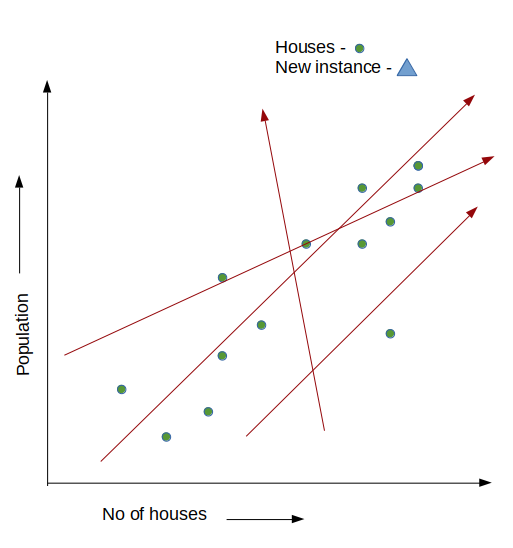

## How the relationship is identified?

To find the realtionship between variable, linear regression creates a hypothesis function-

#### y = h(x) = theta(1) +theta(2)x

where y-> population x -> No of houses

As shown in the above diagram, we can take various values of theta but we need h(x) such that it best fits the data. To find the most optimum values of theta we try to minimize the cost function and the most common cost function is the mean square error function-

#### J(theta) = 1/(2*m)( (y-theta )**2)

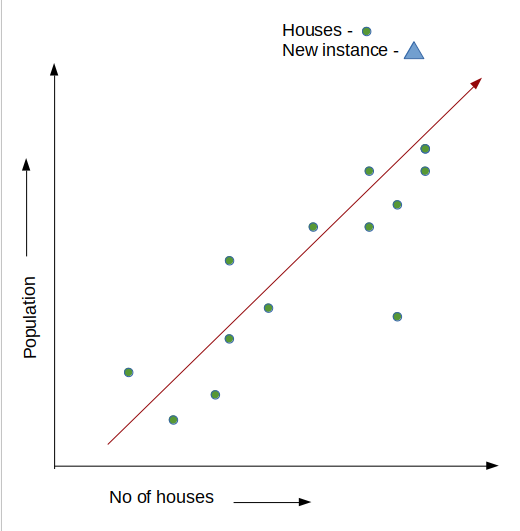

Then for new value of independent variable the dependent variable is predicted using the hypothesis. The following diagram shows how the population is predicted for new instances.

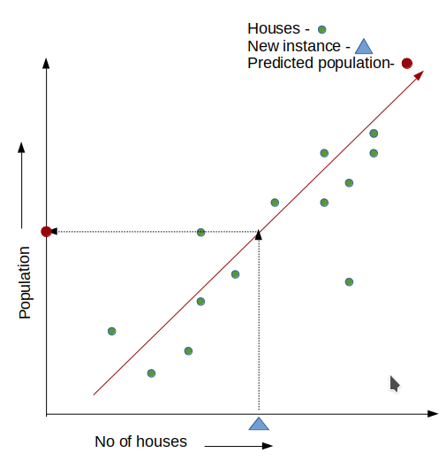

## Python implementation of Linear regression

```python
import numpy as np
import matplotlib.pyplot as plt
```

```python
data = [
    [12,200],
    [24,350],
    [25, 360],
    [30,400],
    [22,300],
    [20,250],
    [27,367],
    [10,280],
    [3,200],
    [7,100],
    [31,432]
]
data = np.array(data)

houses = data[:, :-1]
population = data[:, 1]
```

#### In this cell we will split the data into training and testing set using sklearn library

```python
from sklearn.model_selection import train_test_split
X_train, X_test, y_train, y_test = train_test_split(houses, population, test_size = 1/3, random_state = 0)
```

#### In the next cell we will create our model and fit it in our data

```python
#Importing LinearRegression model
from sklearn.linear_model import LinearRegression
#Creating object of the LinearRegression class
regressor = LinearRegression()
#Fitting the regressor with the training data
regressor.fit(X_train, y_train)
```

```
LinearRegression(copy_X=True, fit_intercept=True, n_jobs=None,
         normalize=False)
```

#### Now we will predict population for unknown data(X_test)

```python
y_pred = regressor.predict(X_test)
print(y_pred)
```

```
[321.33026634 212.94891041 343.00653753 386.3590799 ]
```

#### Now we will plot a graph for training data and hypothesis

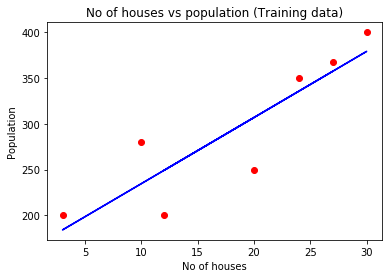

```python
plt.scatter(X_train, y_train, color = 'red')
plt.plot(X_train, regressor.predict(X_train), color = 'blue')
plt.title('No of houses vs population (Training data)')
plt.xlabel('No of houses')
plt.ylabel('Population')
plt.show()
```

#### Now lets plot the same graph for test data

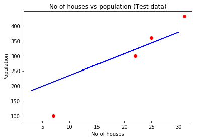

```
Population- [321.33026634 212.94891041 343.00653753 386.3590799 ]
for no of predicted houses
 [[22]
 [ 7]
 [25]
 [31]]
```

```python
plt.scatter(X_test, y_test, color = 'red')
plt.plot(X_train, regressor.predict(X_train), color = 'blue')
plt.title('No of houses vs population (Test data)')
plt.xlabel('No of houses')
plt.ylabel('Population')
plt.show()
print("Population-" ,y_pred ,"\nfor no of predicted houses \n" , X_test)
```